Exploratory Data Analysis 4/2/2020

# Today’s Files

Before we get started, download the zip file containing the filled-in script, the skeleton script, printable version of our work for today, the project file, and the data file (csv).

Unzip the file and then click on the project file to begin

[Download the Files for Today's Class](https://github.com/HSL-Data/BIMS_8382_Web/blob/master/public/zips/BIMS8382_EDA.zip?raw=true)

## Setting Global Rmarkdown Settings

# Exploratory Data Analysis

This lesson will show you how to use R to explore your data in a programmatic, systematic, and visual way. The main goals of exploratory data analysis are to generate questions about your data, search for answers within your data, and then refine or create new questions. This is a very iterative process that will take both programmatic tools and visual tools. Even if you already have questions that you want to know about with your data, exploratory data analysis can still be used to ensure that you have clean data and that the data meets expectations.

## Getting Started

Let’s start by reading in our `olympics` dataset using the `read_csv` function which we get from the tidyverse package. We are going to use this dataset to look at what countries have been the most successful at the olympics and to determine what is the best metric to define “success”

Notice the `message = FALSE`. It suppresses the message that talks about the shape of the olympics dataset. These messages can be helpful to you, the coder, but sometimes they aren’t that useful or necessary for someone else who might be reading your output.

```r
library(tidyverse)
olympics <- read_csv("olympics.csv")
```

## Initial Exploration of our Data

The first thing we are going to do is explore the data at a high level using some of our basic functions. We are going to start programatically and then move back and forth with exploring visually.

```r
olympics %>% names()
```

```
##  [1] "country"   "continent" "pop"       "number"    "gold"      "silver"
##  [7] "bronze"    "number_1"  "gold_1"    "silver_1"  "bronze_1"
```

```r
#Note 1 -> column names for summer or winter

olympics$country %>% head()
```

```
## [1] "Afghanistan" "Algeria"     "Argentina"   "Australia"   "Austria"
## [6] "Bahrain"
```

```r
olympics %>% tail()
```

```
## # A tibble: 6 x 11
##   country continent    pop number  gold silver bronze number_1 gold_1 silver_1
##   <chr>   <chr>      <dbl>  <dbl> <dbl>  <dbl>  <dbl>    <dbl>  <dbl>    <dbl>
## 1 United~ Americas  1.58e5     26   976    757    666       22     96      102
## 2 Uruguay Americas  2.25e3     20     2      2      6        1     NA       NA
## 3 Venezu~ Americas  5.44e3     17     2      2      8        4     NA       NA
## 4 Vietnam Asia      2.62e4     14    NA      2     NA       NA     NA       NA
## 5 Zambia  Africa    2.67e3     12    NA      1      1       NA     NA       NA
## 6 Zimbab~ Africa    3.08e3     12     3      4      1        1     NA       NA
## # ... with 1 more variable: bronze_1 <dbl>
```

```r
#Note 2 -> Totals at the bottom

olympics %>% count(gold_1) %>% arrange(desc(n)) %>% head(1)
```

```
## # A tibble: 1 x 2
##   gold_1     n
##    <dbl> <int>
## 1     NA    75
```

```r
#Note 3 -> Many nas
```

## Renaming Variable Names

The `rename` function allows you to rename variable names. It is important to have informative and consistent column names. The syntax for the rename function is that the “newname” = “oldname”

```r
olympics <- olympics %>%
  rename("number_summer" = "number")

# You can also provide a series of names that you would want to rename
oldnames <- c("gold", "silver", "bronze")
# paste and paste0 join together characters/strings
print(paste0("test", "this"))
```

```
## [1] "testthis"
```

```r
# rename_at is a variation of rename that allows you to specify types of columns to be renamed
olympics <- olympics %>%
  rename_at(vars(oldnames), ~paste0(oldnames, "_summer"))

oldnames <- c("number", "gold", "silver", "bronze")
olympics <- olympics %>%
  rename_at(vars(paste0(oldnames, "_1")), ~ paste0(oldnames, "_winter"))

names(olympics)
```

```
##  [1] "country"       "continent"     "pop"           "number_summer"
##  [5] "gold_summer"   "silver_summer" "bronze_summer" "number_winter"
##  [9] "gold_winter"   "silver_winter" "bronze_winter"
```

Now that we have the variable names looking the way that we want we are going to explore our data visually.

## Basic Exploratory Plotting

Exploring the data programatically is quite helpful, however, sometimes a picture can be worth a thousand words. This section will tie together the use of dplyr with the use data visualization. The exploratory data analysis process is iterative and we will go through how we can use our dplyr results to inform our visualizations and use the results from our visualizations to inform our use of dplyr functions.

In this section I am going to introduce a few plot types that will be helpful when it comes to data exploration and EDA. Future sessions will expand on the plotting capabilities of R.

The main reasons to use plots in Exploratory Data Analysis is to check for missing data, check for outliers, check for the typical values, and to get an overall handle of your data.

## Histogram/Density

The first plot we are going ot create is a histogram plot that is valuable in visualizing distributions and in looking for typical values/outliers.

To start a plot using ggplot(), we first build a base/canvas using the ggplot function. We provide the function with a dataset and then map variables from that dataset onto the x and y axes. In this section we will be using the ggplot function and then the following two key aspects of using ggplot:

- a **geom**, which specifies how the data are represented on the plot (points, lines, bars, etc.),
- **aesthetics** that map variables in the data to axes on the plot or to plotting size, shape, color, etc.,

Let us first build a histogram looking at the distribution of gold medals won in the summer.

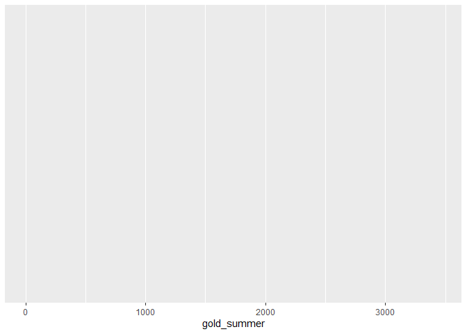

```r
#First build a canvas using the olympics dataset and the gold_summer variable on our x axis
ggplot(data = olympics, aes(x = gold_summer))
```

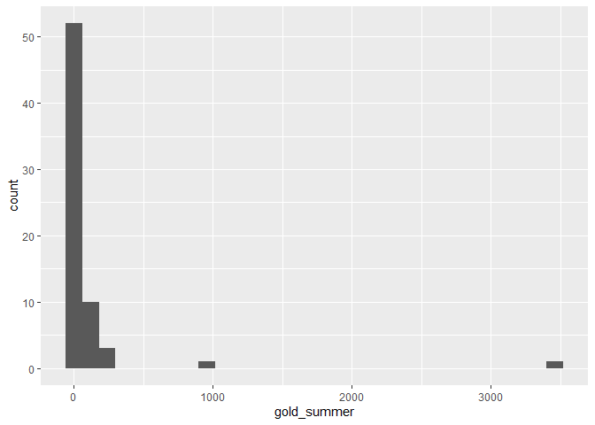

```r
#From there, we can tell ggplot to use a histogram to plot our values from gold_smmer
ggplot(data = olympics, aes(x = gold_summer)) + geom_histogram()
```

```r
#Looking at this visualization, we can see that most of our data falls under 25 gold medals during the summer olympics with a single outlier all the way out at around 1000 gold medals old and another past 3000. Let's look at how the two outliers might be messing up our mean
olympics %>%
  summarize(mean(gold_summer), median(gold_summer))
```

```
## # A tibble: 1 x 2
##   `mean(gold_summer)` `median(gold_summer)`
##                 <dbl>                 <dbl>
## 1                  NA                    NA
```

```r
#Notice 30 rows were removed during the creation of the histogram. These were dropped because they were missing data.
olympics %>%
  summarize(mean(gold_summer, na.rm = TRUE), median(gold_summer, na.rm = TRUE))
```

```
## # A tibble: 1 x 2
##   `mean(gold_summer, na.rm = TRUE)` `median(gold_summer, na.rm = TRUE)`
##                               <dbl>                               <dbl>
## 1                              52.5                                13.5
```

```r
#The small amount of gold medals could be driven by countries that haven't been in that many summer games. We can filter and look only at countries that have been in the games over 10 times.
olympics %>%
  filter(number_summer > 10) %>%
  summarize(mean(gold_summer, na.rm = TRUE), median(gold_summer, na.rm = TRUE))
```

```
## # A tibble: 1 x 2
##   `mean(gold_summer, na.rm = TRUE)` `median(gold_summer, na.rm = TRUE)`
##                               <dbl>                               <dbl>
## 1                              54.8                                  17
```

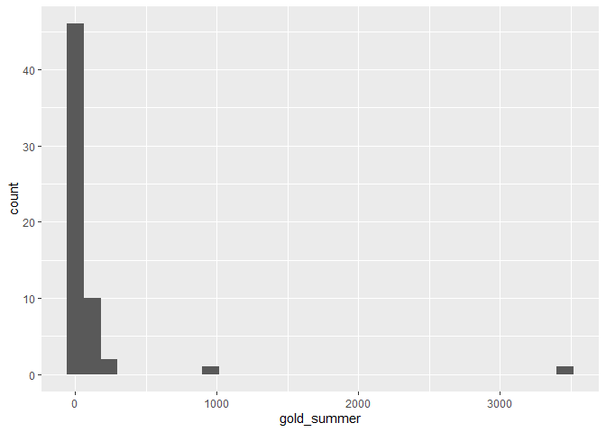

```r
#We can feed this filtered dataset right into ggplot.
olympics %>%
  filter(number_summer > 10) %>%
  ggplot(aes(x = gold_summer)) + geom_histogram()
```

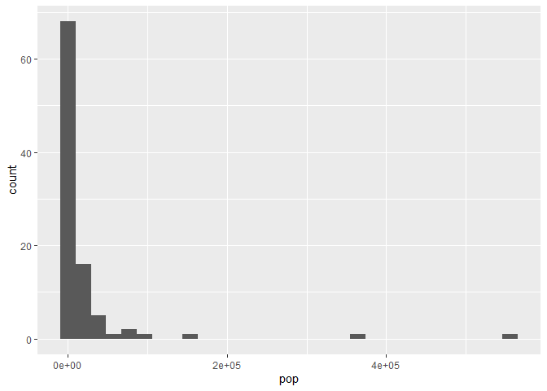

```r
#Doesn't change the shape much, only the count

#Let us take a look at another variable, the population of each country
ggplot(data = olympics, aes(pop)) + geom_histogram()
```

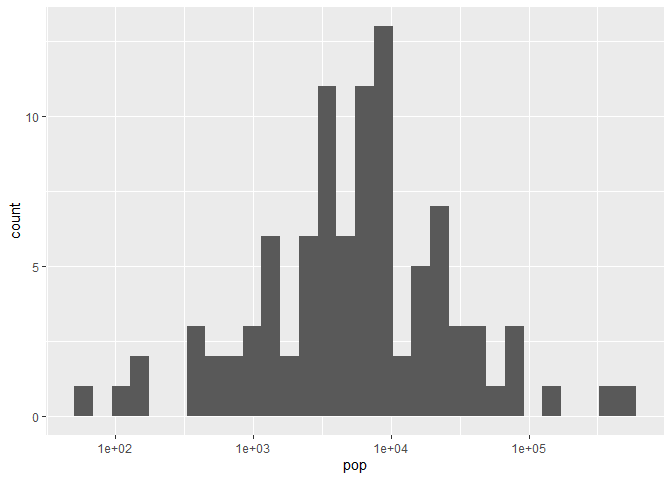

```r
#This is quite skewed, so scaling does help.
ggplot(data = olympics, aes(pop)) + geom_histogram() + scale_x_log10()
```

```r
#population per 1000 does give us an idea that maybe we could look at population and medals together, since there are a few countries with a much larger population than others

#Instead of a histogram you can also use a density plot which is a smoothed version of the histogram.
olympics %>%
  arrange(desc(pop)) %>%
  select(pop)
```

```
## # A tibble: 96 x 1
##        pop
##      <dbl>
##  1 556264.
##  2 372000
##  3 157553
##  4  86459.
##  5  82052
##  6  69146.
##  7  56603.
##  8  47666
##  9  42460.
## 10  41347.
## # ... with 86 more rows
```

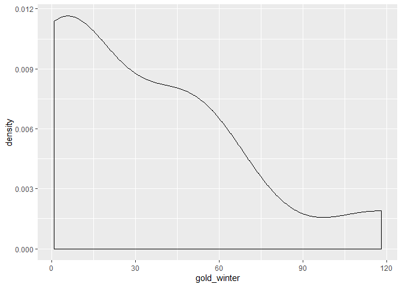

```r
olympics %>%
  filter(pop < 10000) %>%
  ggplot(aes(gold_winter)) + geom_density()
```

## Making Changes to our Data

## Mutate

To create new variables or change variables in place, we are going to use dplyr’s `mutate()` function. Just like the other dplyr verbs we learned, `filter()` and `select()`, `mutate()` takes a dataframe as the first argument and then the name of the new variable followed by a function to create the new variable. Remember, these functions don’t modify the data frame you’re operating on, and the result is transient unless you assign it to a new object or reassign it back to itself (not always a good practice).

Let’s use `mutate()` to calculate a few extra variables.

```r
#Normal Math
olympics %>%
  mutate(total_gold = gold_summer + gold_winter) %>%
  select(total_gold)
```

```
## # A tibble: 96 x 1
##    total_gold
##         <dbl>
##  1         NA
##  2         NA
##  3         NA
##  4        144
##  5         77
##  6         NA
##  7         38
##  8         NA
##  9         NA
## 10         52
## # ... with 86 more rows
```

```r
#NAs are at it again.
#In this case nas are 0
#mutate_if
olympics <- olympics %>%
  mutate_if(is.numeric, replace_na, 0)

#We have taken care of the nas
olympics %>%
  mutate(total_gold = gold_summer + gold_winter) %>%
  select(total_gold)
```

```
## # A tibble: 96 x 1
##    total_gold
##         <dbl>
##  1          0
##  2          5
##  3         18
##  4        144
##  5         77
##  6          0
##  7         38
##  8          0
##  9         23
## 10         52
## # ... with 86 more rows
```

```r
#You can also use the mutate_if function if you want to change all character vectors to factor vectors, all numeric to character, etc.
olympics %>%
  mutate_if(is.character, as.factor)
```

```
## # A tibble: 96 x 11
##    country continent    pop number_summer gold_summer silver_summer
##    <fct>   <fct>      <dbl>         <dbl>       <dbl>         <dbl>
##  1 Afghan~ Asia       8425.            13           0             0
##  2 Algeria Africa     9280.            12           5             2
##  3 Argent~ Americas  17877.            23          18            24
##  4 Austra~ Oceania    8691.            25         139           152
##  5 Austria Europe     6928.            26          18            33
##  6 Bahrain Asia        120.             8           0             0
##  7 Belgium Europe     8730.            25          37            52
##  8 Botswa~ Africa      442.             9           0             1
##  9 Brazil  Americas  56603.            21          23            30
## 10 Bulgar~ Europe     7275.            19          51            85
## # ... with 86 more rows, and 5 more variables: bronze_summer <dbl>,
## #   number_winter <dbl>, gold_winter <dbl>, silver_winter <dbl>,
## #   bronze_winter <dbl>
```

```r
#Here we can calculate the total numbers across summer and winter. You can do multiple calculations by separating by commas. As a note, each variable is created in order. So we can create a column in the first portion of the mutate function and use it down the line.
olympics <- olympics %>%
  mutate(total_gold   = gold_summer + gold_winter,
         total_silver = silver_summer + silver_winter,
         total_bronze = bronze_summer + bronze_winter,
         total_number = number_summer + number_winter,
         total_winter = gold_winter + silver_winter + bronze_winter,
         total_summer = gold_summer + silver_summer + bronze_summer,
         total_medals = total_gold + total_silver + total_bronze)

#Using if-else
olympics %>%
  mutate(more_winter = ifelse(gold_winter > gold_summer, 1, 0)) %>%
  select(country, gold_winter, gold_summer, more_winter)
```

```
## # A tibble: 96 x 4
##    country     gold_winter gold_summer more_winter
##    <chr>             <dbl>       <dbl>       <dbl>
##  1 Afghanistan           0           0           0
##  2 Algeria               0           5           0
##  3 Argentina             0          18           0
##  4 Australia             5         139           0
##  5 Austria              59          18           1
##  6 Bahrain               0           0           0
##  7 Belgium               1          37           0
##  8 Botswana              0           0           0
##  9 Brazil                0          23           0
## 10 Bulgaria              1          51           0
## # ... with 86 more rows
```

## case_when

The `case_when()` function is a helpful function that allows you run through several conditions all at once. Much easier to read than trying to nest a whole bunch of ifelse statements

```r
#case_when - Grouping by Low to Very High based off of total_medals
olympics <- olympics %>%
  mutate(medal_group = case_when(
    total_medals < 15 ~ "Low",
    total_medals >= 15 & total_medals < 50 ~ "Medium",
    total_medals >= 50 & total_medals < 200 ~ "High",
    total_medals >= 200 ~ "Very High"))

olympics %>%
  count(medal_group) %>%
  print(n = Inf)
```

```
## # A tibble: 4 x 2
##   medal_group     n
##   <chr>       <int>
## 1 High           14
## 2 Low            48
## 3 Medium         15
## 4 Very High      19
```

## Filter

The filter function is very useful for data cleaning and data exploration.

```r
#Filter out the Totals
olympics <- olympics %>%
  filter(country != "Totals")

#Let's only look at those countries that have been to 5 summer games and 5 winter games and who have at least won 10 medals
olympics <- olympics %>%
  filter(number_summer >= 5 & number_winter >= 5) %>%
  filter(total_medals >= 10)
```

### Exercise

1. Create variables for the average amount of medals won for each olympics attended during the summer games, the winter games, and both combined.
2. Create a variable showing the percentage of total medals won during the summer games?
3. Create a variable that has four levels of population - “Low” - less than 5343 “Average” - between 5343 and 9721 “High” - between 9721 and 27845 “Very High” - greater than 27845

**Click here for the answers**

```r
olympics <- olympics %>%
  mutate(aver_summer = total_summer/number_summer,
         aver_winter = total_winter/number_winter,
         aver_total = total_medals/(number_summer + number_winter),
         perc_summer = total_summer/total_medals * 100)

summary(olympics$pop)
```

```
##     Min.  1st Qu.   Median     Mean  3rd Qu.     Max.
##    800.7   5596.3   9504.0  43720.2  27140.2 556263.5
```

```r
olympics <- olympics %>%
  mutate(pop_group = case_when(
    pop < 5343 ~ "Low",
    pop >=5343 & pop < 9721 ~ "Average",
    pop >= 9721 & pop < 27845 ~ "High",
    pop >= 27845 ~ "Very High"
  ))
```